# Data Analysis Case Study

Alexandra Chronopoulou

This is a complete analysis of the `prostate.txt` data set.

## Prostate Data Analysis

Serum prostate-specific antigen (PSA) was determined in 97 men with advanced prostate cancer. PSA is a well-established screening test for prostate cancer. The oncologists wanted to examine the *correlation* between `level of PSA` and a number of clinical measures for men who were about to undergo a radical prostatectomy. The measures are `cancer volume`, `patient age`, the `amount of bening prostatic hyperplasia`, `seminal vesicle invasion`, `capsular penetration` and `Gleason score`.

We start by loading the necessary packages in R. We choose `warning=FALSE` and `message=FALSE` to keep the output clean.

```r
library(dplyr)
library(faraway)
library(lmtest)
library(MASS)
```

We take a first look at the data:

```r
psa.data = read.table("prostate.txt", header=FALSE)
head(psa.data)
```

```
##   V1    V2     V3     V4 V5 V6 V7 V8 V9
## 1  1 0.651 0.5599 15.959 50  0  0  0  6
## 2  2 0.852 0.3716 27.660 58  0  0  0  7
## 3  3 0.852 0.6005 14.732 74  0  0  0  7
## 4  4 0.852 0.3012 26.576 58  0  0  0  6
## 5  5 1.448 2.1170 30.877 62  0  0  0  6
## 6  6 2.160 0.3499 25.280 50  0  0  0  6
```

We notice that the columns have no labels. It is hard to interpret a model with generic notation. So, we change the names of the variables and give them a code name that reminds us of the nature of the variables. For that purpose, we use the `rename` function from the `dplyr` library.

```r
psa.data = rename(psa.data, ID = V1)
psa.data = rename(psa.data, psalevel = V2)
psa.data = rename(psa.data, cancervolume = V3)
psa.data = rename(psa.data, prostateweight = V4)
psa.data = rename(psa.data, age = V5)
psa.data = rename(psa.data, hyperplasia = V6)
psa.data = rename(psa.data, svi = V7)
psa.data = rename(psa.data, capsular = V8)
psa.data = rename(psa.data, gleason = V9)

head(psa.data)
```

```
##   ID psalevel cancervolume prostateweight age hyperplasia svi capsular gleason
## 1  1    0.651       0.5599         15.959  50           0   0        0       6
## 2  2    0.852       0.3716         27.660  58           0   0        0       7
## 3  3    0.852       0.6005         14.732  74           0   0        0       7
## 4  4    0.852       0.3012         26.576  58           0   0        0       6
## 5  5    1.448       2.1170         30.877  62           0   0        0       6
## 6  6    2.160       0.3499         25.280  50           0   0        0       6
```

Before starting to build regression models, we take a closer look at the variables. We want to see the type of variables we have and whether there is a linear relation with the chosen response, `psalevel` according to the description of the problem.

```r
summary(psa.data)
```

```
##        ID        psalevel        cancervolume     prostateweight
##  Min.   : 1   Min.   :  0.651   Min.   : 0.2592   Min.   : 10.70
##  1st Qu.:25   1st Qu.:  5.641   1st Qu.: 1.6653   1st Qu.: 29.37
##  Median :49   Median : 13.330   Median : 4.2631   Median : 37.34
##  Mean   :49   Mean   : 23.730   Mean   : 6.9987   Mean   : 45.49
##  3rd Qu.:73   3rd Qu.: 21.328   3rd Qu.: 8.4149   3rd Qu.: 48.42
##  Max.   :97   Max.   :265.072   Max.   :45.6042   Max.   :450.34
##       age         hyperplasia          svi            capsular
##  Min.   :41.00   Min.   : 0.000   Min.   :0.0000   Min.   : 0.0000
##  1st Qu.:60.00   1st Qu.: 0.000   1st Qu.:0.0000   1st Qu.: 0.0000
##  Median :65.00   Median : 1.350   Median :0.0000   Median : 0.4493
##  Mean   :63.87   Mean   : 2.535   Mean   :0.2165   Mean   : 2.2454
##  3rd Qu.:68.00   3rd Qu.: 4.759   3rd Qu.:0.0000   3rd Qu.: 3.2544
##  Max.   :79.00   Max.   :10.278   Max.   :1.0000   Max.   :18.1741
##     gleason
##  Min.   :6.000
##  1st Qu.:6.000
##  Median :7.000
##  Mean   :6.876
##  3rd Qu.:7.000
##  Max.   :8.000
```

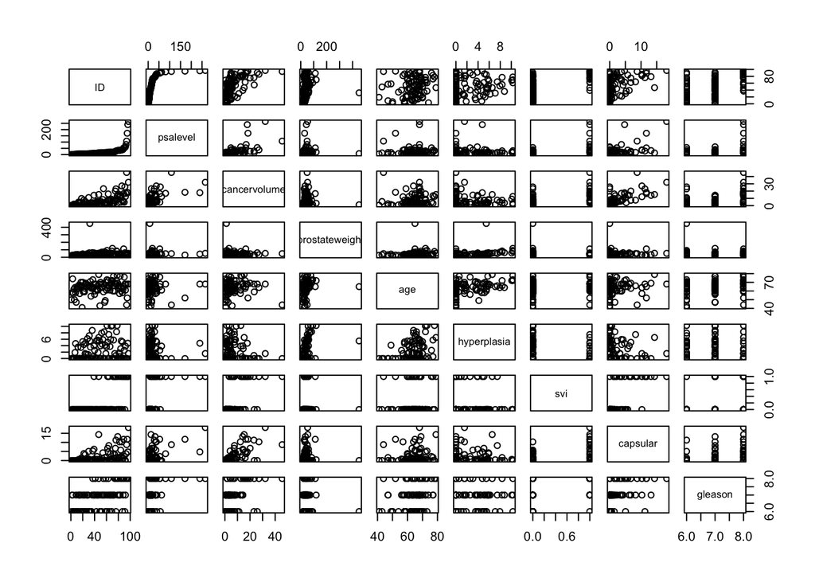

```r
pairs(psa.data)
```

The variable `svi` is the only categorical variable in the data set, and has levels 0 and 1. Although we have not taked about categorial predictors yet, we will keep it in the model and treat it like any other variable.

We fit our full model to get an idea of the fit of the regression line:

```r
full.model =  lm(psalevel ~ cancervolume + prostateweight + age + hyperplasia + svi + capsular + gleason, data=psa.data)
summary(full.model)
```

```
##
## Call:
## lm(formula = psalevel ~ cancervolume + prostateweight + age +
##     hyperplasia + svi + capsular + gleason, data = psa.data)
##
## Residuals:
##     Min      1Q  Median      3Q     Max
## -61.330  -8.130  -0.014   6.324 167.436
##
## Coefficients:
##                 Estimate Std. Error t value Pr(>|t|)
## (Intercept)    -15.24264   40.53932  -0.376 0.707814
## cancervolume     2.03225    0.59359   3.424 0.000936 ***
## prostateweight   0.01132    0.07395   0.153 0.878708
## age             -0.53721    0.47588  -1.129 0.261977
## hyperplasia      1.29831    1.20168   1.080 0.282878
## svi             19.60957   10.89184   1.800 0.075187 .
## capsular         1.09877    1.33377   0.824 0.412253
## gleason          7.05922    5.19452   1.359 0.177589
## ---
## Signif. codes:  0 '***' 0.001 '**' 0.01 '*' 0.05 '.' 0.1 ' ' 1
##
## Residual standard error: 31.17 on 89 degrees of freedom
## Multiple R-squared:  0.4585, Adjusted R-squared:  0.4159
## F-statistic: 10.77 on 7 and 89 DF,  p-value: 9.266e-10
```

The $R^2$ is not high, and among all variables only the `cancervolume` seems to be statistically significant. We check the correlation matrix of the predictors to identify presence of collinearity.

```r
cor(psa.data[,-c(1,2)])
```

```
##                cancervolume prostateweight        age hyperplasia          svi
## cancervolume    1.000000000    0.005107148 0.03909442 -0.13320943  0.581741687
## prostateweight  0.005107148    1.000000000 0.16432371  0.32184875 -0.002410475
## age             0.039094423    0.164323714 1.00000000  0.36634121  0.117658038
## hyperplasia    -0.133209431    0.321848748 0.36634121  1.00000000 -0.119553192
## svi             0.581741687   -0.002410475 0.11765804 -0.11955319  1.000000000
## capsular        0.692896688    0.001578905 0.09955535 -0.08300865  0.680284092
## gleason         0.481438397   -0.024206925 0.22585181  0.02682555  0.428573479
##                    capsular     gleason
## cancervolume    0.692896688  0.48143840
## prostateweight  0.001578905 -0.02420693
## age             0.099555351  0.22585181
## hyperplasia    -0.083008649  0.02682555
## svi             0.680284092  0.42857348
## capsular        1.000000000  0.46156590
## gleason         0.461565896  1.00000000
```

We observe that `cancervolume` is mildly correlated with `svi`, `capsular` and `gleason.` We cannot make any conclusions, so we proceed with our analysis.

We now start removing variables that are not statistically significant from the model. We either remove them one-by-one or we use the partial $F$ to test “out” more than one variables.

```r
model1 =  lm(psalevel ~ cancervolume  + age + hyperplasia + svi + capsular + gleason, data=psa.data)
summary(model1)
```

```
##
## Call:
## lm(formula = psalevel ~ cancervolume + age + hyperplasia + svi +
##     capsular + gleason, data = psa.data)
##
## Residuals:
##     Min      1Q  Median      3Q     Max
## -61.491  -8.199  -0.080   5.923 167.267
##
## Coefficients:
##              Estimate Std. Error t value Pr(>|t|)
## (Intercept)  -14.7460    40.1894  -0.367 0.714545
## cancervolume   2.0375     0.5894   3.457 0.000836 ***
## age           -0.5327     0.4724  -1.128 0.262448
## hyperplasia    1.3518     1.1434   1.182 0.240209
## svi           19.6441    10.8303   1.814 0.073038 .
## capsular       1.0974     1.3265   0.827 0.410273
## gleason        6.9942     5.1489   1.358 0.177741
## ---
## Signif. codes:  0 '***' 0.001 '**' 0.01 '*' 0.05 '.' 0.1 ' ' 1
##
## Residual standard error: 31 on 90 degrees of freedom
## Multiple R-squared:  0.4584, Adjusted R-squared:  0.4223
## F-statistic:  12.7 on 6 and 90 DF,  p-value: 2.481e-10
```

```r
model2 =  lm(psalevel ~ cancervolume  + age + hyperplasia + svi  + gleason, data=psa.data)
summary(model2)
```

```
##
## Call:
## lm(formula = psalevel ~ cancervolume + age + hyperplasia + svi +
##     gleason, data = psa.data)
##
## Residuals:
##     Min      1Q  Median      3Q     Max
## -54.839  -8.758   0.206   5.181 163.883
##
## Coefficients:
##              Estimate Std. Error t value Pr(>|t|)
## (Intercept)  -18.4353    39.8719  -0.462   0.6449
## cancervolume   2.2595     0.5238   4.313 4.07e-05 ***
## age           -0.5261     0.4715  -1.116   0.2674
## hyperplasia    1.3714     1.1412   1.202   0.2326
## svi           23.6477     9.6720   2.445   0.0164 *
## gleason        7.4688     5.1080   1.462   0.1471
## ---
## Signif. codes:  0 '***' 0.001 '**' 0.01 '*' 0.05 '.' 0.1 ' ' 1
##
## Residual standard error: 30.94 on 91 degrees of freedom
## Multiple R-squared:  0.4543, Adjusted R-squared:  0.4243
## F-statistic: 15.15 on 5 and 91 DF,  p-value: 8.245e-11
```

```r
model1b =  lm(psalevel ~ cancervolume  + age + hyperplasia + svi  + gleason , data=psa.data)
summary(model1b)
```

```
##
## Call:
## lm(formula = psalevel ~ cancervolume + age + hyperplasia + svi +
##     gleason, data = psa.data)
##
## Residuals:
##     Min      1Q  Median      3Q     Max
## -54.839  -8.758   0.206   5.181 163.883
##
## Coefficients:
##              Estimate Std. Error t value Pr(>|t|)
## (Intercept)  -18.4353    39.8719  -0.462   0.6449
## cancervolume   2.2595     0.5238   4.313 4.07e-05 ***
## age           -0.5261     0.4715  -1.116   0.2674
## hyperplasia    1.3714     1.1412   1.202   0.2326
## svi           23.6477     9.6720   2.445   0.0164 *
## gleason        7.4688     5.1080   1.462   0.1471
## ---
## Signif. codes:  0 '***' 0.001 '**' 0.01 '*' 0.05 '.' 0.1 ' ' 1
##
## Residual standard error: 30.94 on 91 degrees of freedom
## Multiple R-squared:  0.4543, Adjusted R-squared:  0.4243
## F-statistic: 15.15 on 5 and 91 DF,  p-value: 8.245e-11
```

```r
anova(model1b, full.model)
```

```
## Analysis of Variance Table
##
## Model 1: psalevel ~ cancervolume + age + hyperplasia + svi + gleason
## Model 2: psalevel ~ cancervolume + prostateweight + age + hyperplasia +
##     svi + capsular + gleason
##   Res.Df   RSS Df Sum of Sq      F Pr(>F)
## 1     91 87138
## 2     89 86457  2    680.36 0.3502 0.7055
```

For illustration purposes, we will continue with `model 2` to check model assumptions.

We start with detection of unusual observations:

```r
## Diagnostics for model 2

n=dim(psa.data)[1]; # sample size
p=6;

# Compute Leverages
lev=influence(model2)$hat

# Determine which exceed the 2p/n threshold
newlev = lev[lev>2*p/n]
length(newlev)/n
```

```
## [1] 0.04123711
```

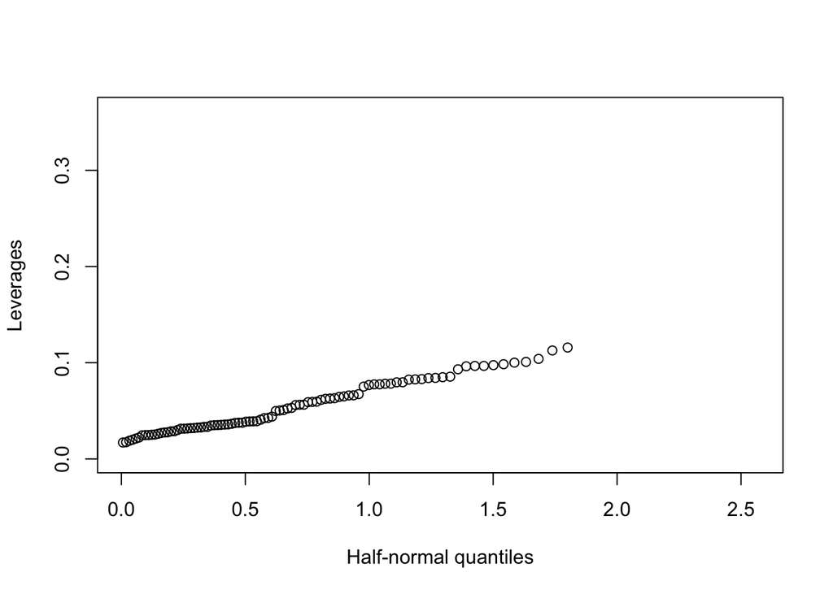

```r
# Prepare a half-normal plot
halfnorm(lev, 6, labs=as.character(1:length(newlev)), ylab="Leverages")
```

```r
# Compute Studentized Residuals
jack=rstudent(model2);

# The critical value WITH Bonferroni correction is
qt(.05/(2*n), n-p-1)
```

```
## [1] -3.602782
```

```r
# The critical value WITHOUT Bonferroni correction is
qt(.05/2, n-p-1)
```

```
## [1] -1.986675
```

```r
# Sort the residuals indescending order to find outliers (if any)
sort(abs(jack), decreasing=TRUE)[1:10]
```

```
##       97       96       95       86       47       39       55       75
## 6.779304 6.642788 3.278295 1.877158 1.855789 1.693266 1.677037 1.599902
##       94       76
## 1.510187 1.392494
```

```r
#There are 2 outliers: #96, #97

# Compute Cook's Distance
cook = cooks.distance(model2)
# Extract max Cook's Distance
max(cook)
```

```
## [1] 0.6887442
```

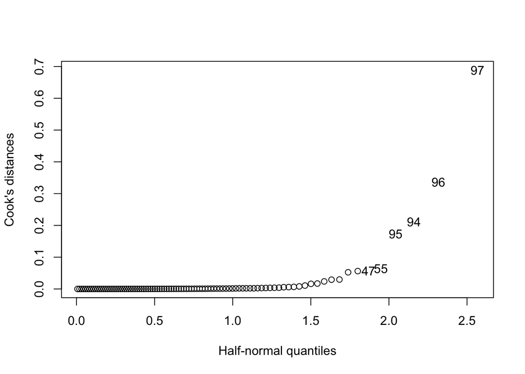

```r
# Prepare a Half Normal Plot of Cook's distances
halfnorm(cook, 6, labs=as.character(1:length(cook)), ylab="Cook's distances")
```

We conclude that there are several high leverage points, but none of them is a “bad” high leverage point. We also have two outliers (obs #96, #97), but we have no influential points.

We proceed with checking constant variance and normality assumptions:

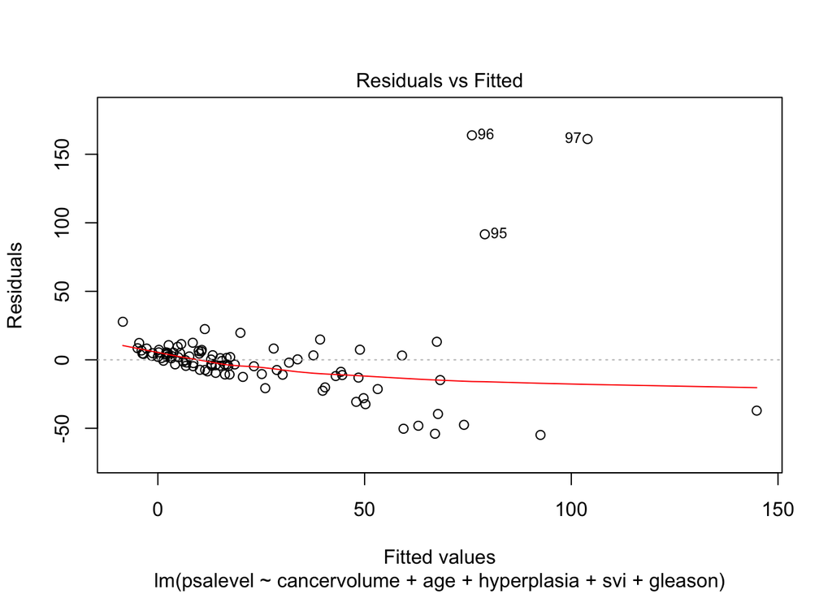

```r
# Checking Homoskedasticity

plot(model2, which=1)
```

```r
bptest(model2)
```

```
##
##  studentized Breusch-Pagan test
##
## data:  model2
## BP = 22.572, df = 5, p-value = 0.0004075
```

Both the graphical check and the statistical Breusch-Pagan test indicate that the variance is not constant.

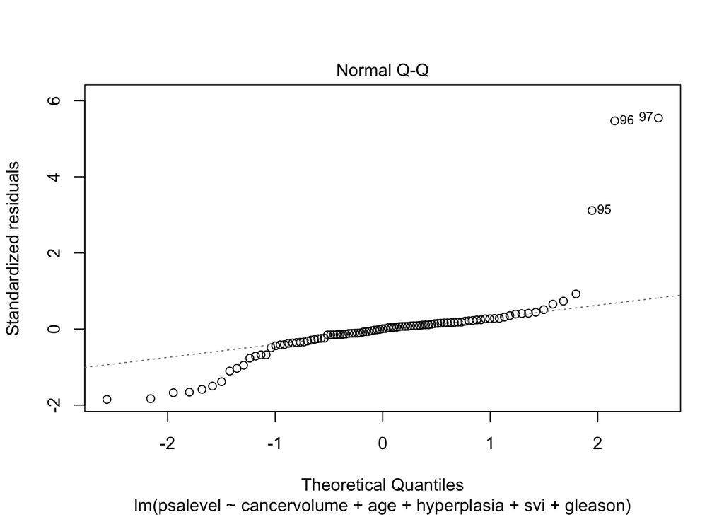

```r
# Normality

plot(model2, which=2)
```

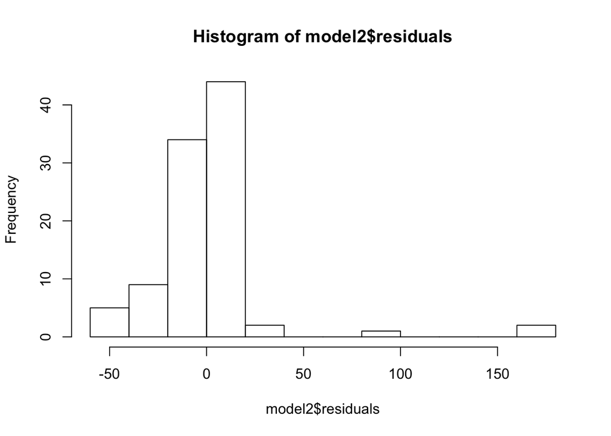

```r
hist(model2$residuals)
```

```r
ks.test(residuals(model2), y=pnorm)
```

```
##
##  One-sample Kolmogorov-Smirnov test
##
## data:  residuals(model2)
## D = 0.42988, p-value = 5.551e-16
## alternative hypothesis: two-sided
```

Both graphical checks and the statistical Kolmogorov-Smirnov test indicate that the normality assumption is not satisfied.

In order to fix one or more of the assumptions we consider transforming the response. We start by looking at a Box-Cox transformation:

```r
# Box Cox Transformation
model.transformation = boxcox(model2, lambda=seq(-2, 2, length=400))
```

[figure not shown]

Since $\lambda=0$ is close to the lower limit of the interval, and since a `log` transform is a transformation that is easy to manipulate and interpret, we proceed with the `log` transformation of the response.

So, the next step here is to repeat all the analysis from scratch. You will observe that we will have a different model now.

```r
model3 = lm(log(psalevel) ~ cancervolume + prostateweight + age + hyperplasia + svi + capsular + gleason, data=psa.data)
summary(model3)
```

```
##
## Call:
## lm(formula = log(psalevel) ~ cancervolume + prostateweight +
##     age + hyperplasia + svi + capsular + gleason, data = psa.data)
##
## Residuals:
##      Min       1Q   Median       3Q      Max
## -1.88309 -0.46629  0.08045  0.47380  1.53219
##
## Coefficients:
##                 Estimate Std. Error t value Pr(>|t|)
## (Intercept)    -0.685796   0.998754  -0.687  0.49409
## cancervolume    0.069454   0.014624   4.749 7.77e-06 ***
## prostateweight  0.001380   0.001822   0.757  0.45079
## age            -0.002799   0.011724  -0.239  0.81186
## hyperplasia     0.087470   0.029605   2.955  0.00401 **
## svi             0.782623   0.268339   2.917  0.00448 **
## capsular       -0.026521   0.032860  -0.807  0.42177
## gleason         0.358153   0.127976   2.799  0.00629 **
## ---
## Signif. codes:  0 '***' 0.001 '**' 0.01 '*' 0.05 '.' 0.1 ' ' 1
##
## Residual standard error: 0.7679 on 89 degrees of freedom
## Multiple R-squared:  0.5893, Adjusted R-squared:  0.557
## F-statistic: 18.24 on 7 and 89 DF,  p-value: 7.694e-15
```

```r
model4 = lm(log(psalevel) ~ cancervolume + prostateweight  + hyperplasia + svi + capsular + gleason, data=psa.data)
summary(model4)
```

```
##
## Call:
## lm(formula = log(psalevel) ~ cancervolume + prostateweight +
##     hyperplasia + svi + capsular + gleason, data = psa.data)
##
## Residuals:
##      Min       1Q   Median       3Q      Max
## -1.87226 -0.46558  0.08206  0.46484  1.50784
##
## Coefficients:
##                 Estimate Std. Error t value Pr(>|t|)
## (Intercept)    -0.817763   0.827461  -0.988  0.32567
## cancervolume    0.069705   0.014510   4.804 6.17e-06 ***
## prostateweight  0.001353   0.001809   0.748  0.45643
## hyperplasia     0.085103   0.027750   3.067  0.00286 **
## svi             0.777115   0.265941   2.922  0.00440 **
## capsular       -0.026656   0.032682  -0.816  0.41688
## gleason         0.352362   0.124995   2.819  0.00592 **
## ---
## Signif. codes:  0 '***' 0.001 '**' 0.01 '*' 0.05 '.' 0.1 ' ' 1
##
## Residual standard error: 0.7638 on 90 degrees of freedom
## Multiple R-squared:  0.589,  Adjusted R-squared:  0.5616
## F-statistic:  21.5 on 6 and 90 DF,  p-value: 1.619e-15
```

```r
model5 = lm(log(psalevel) ~ cancervolume   + hyperplasia + svi + capsular + gleason, data=psa.data)
summary(model5)
```

```
##
## Call:
## lm(formula = log(psalevel) ~ cancervolume + hyperplasia + svi +
##     capsular + gleason, data = psa.data)
##
## Residuals:
##      Min       1Q   Median       3Q      Max
## -1.88954 -0.48197  0.08813  0.48409  1.57370
##
## Coefficients:
##              Estimate Std. Error t value Pr(>|t|)
## (Intercept)  -0.73258    0.81760  -0.896 0.372608
## cancervolume  0.07029    0.01445   4.863 4.82e-06 ***
## hyperplasia   0.09198    0.02612   3.522 0.000672 ***
## svi           0.78233    0.26520   2.950 0.004041 **
## capsular     -0.02680    0.03260  -0.822 0.413237
## gleason       0.34568    0.12437   2.779 0.006617 **
## ---
## Signif. codes:  0 '***' 0.001 '**' 0.01 '*' 0.05 '.' 0.1 ' ' 1
##
## Residual standard error: 0.762 on 91 degrees of freedom
## Multiple R-squared:  0.5865, Adjusted R-squared:  0.5637
## F-statistic: 25.81 on 5 and 91 DF,  p-value: 3.931e-16
```

```r
model6 = lm(log(psalevel) ~ cancervolume   + hyperplasia + svi  + gleason, data=psa.data)
summary(model6)
```

```
##
## Call:
## lm(formula = log(psalevel) ~ cancervolume + hyperplasia + svi +
##     gleason, data = psa.data)
##
## Residuals:
##      Min       1Q   Median       3Q      Max
## -1.88531 -0.50276  0.09885  0.53687  1.56621
##
## Coefficients:
##              Estimate Std. Error t value Pr(>|t|)
## (Intercept)  -0.65013    0.80999  -0.803 0.424253
## cancervolume  0.06488    0.01285   5.051 2.22e-06 ***
## hyperplasia   0.09136    0.02606   3.506 0.000705 ***
## svi           0.68421    0.23640   2.894 0.004746 **
## gleason       0.33376    0.12331   2.707 0.008100 **
## ---
## Signif. codes:  0 '***' 0.001 '**' 0.01 '*' 0.05 '.' 0.1 ' ' 1
##
## Residual standard error: 0.7606 on 92 degrees of freedom
## Multiple R-squared:  0.5834, Adjusted R-squared:  0.5653
## F-statistic: 32.21 on 4 and 92 DF,  p-value: < 2.2e-16
```

The model containing `cancervolume`, `hyperplasia`, `svi` and `gleason` is the selected model. We perform diagnostics (again) to check whether the assumptions are now satisfied:

```r
## Diagnostics for Model 6
n=dim(psa.data)[1]; # sample size
p=5;

# Compute Leverages
lev=influence(model6)$hat

# Determine which exceed the 2p/n threshold
newlev = lev[lev>2*p/n]
length(newlev)/n
```

```
## [1] 0.06185567
```

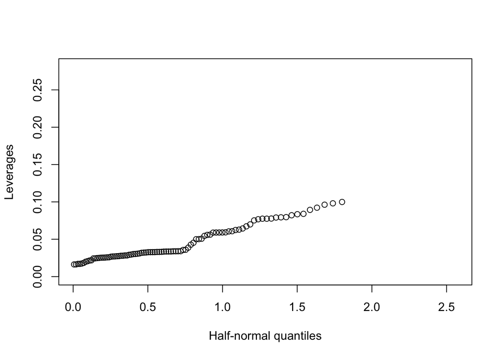

```r
# Prepare a half-normal plot
halfnorm(lev, 6, labs=as.character(1:length(newlev)), ylab="Leverages")
```

```r
# Compute Studentized Residuals
jack=rstudent(model6);

# The critical value WITH Bonferroni correction is
qt(.05/(2*n), n-p-1)
```

```
## [1] -3.601304
```

```r
# Sort the residuals indescending order to find outliers (if any)
sort(abs(jack), decreasing=TRUE)[1:10]
```

```
##        3        2        1       47       69        4       39       81
## 2.598313 2.577400 2.499628 2.427144 2.134505 2.086370 1.993100 1.870276
##       87       95
## 1.861979 1.704555
```

```r
# Compute Cook's Distance
cook = cooks.distance(model6)
# Extract max Cook's Distance
max(cook)
```

```
## [1] 0.1809441
```

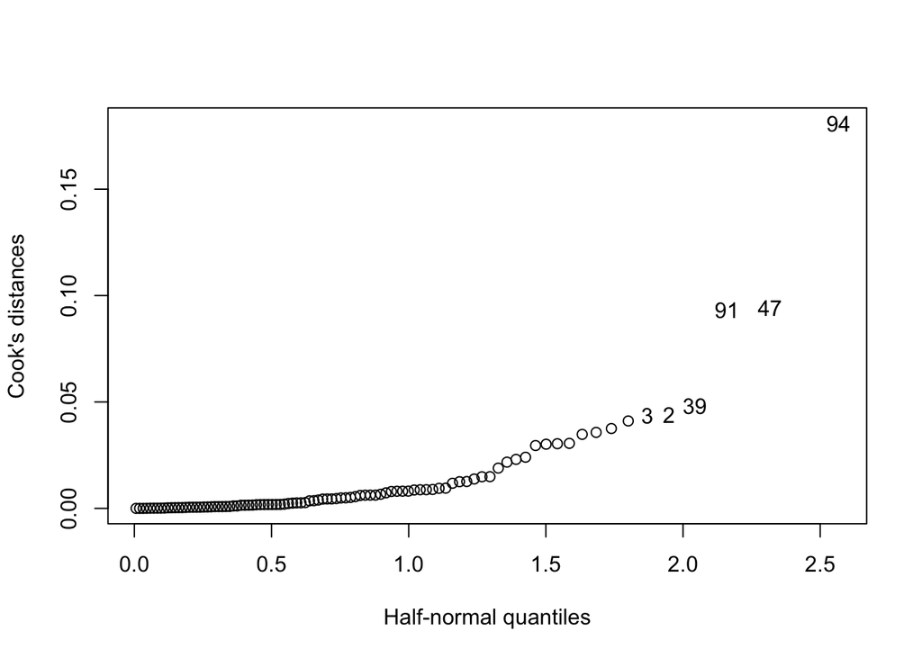

```r
# Prepare a Half Normal Plot of Cook's distances
halfnorm(cook, 6, labs=as.character(1:length(cook)), ylab="Cook's distances")
```

In the transformed model, we have no outliers.

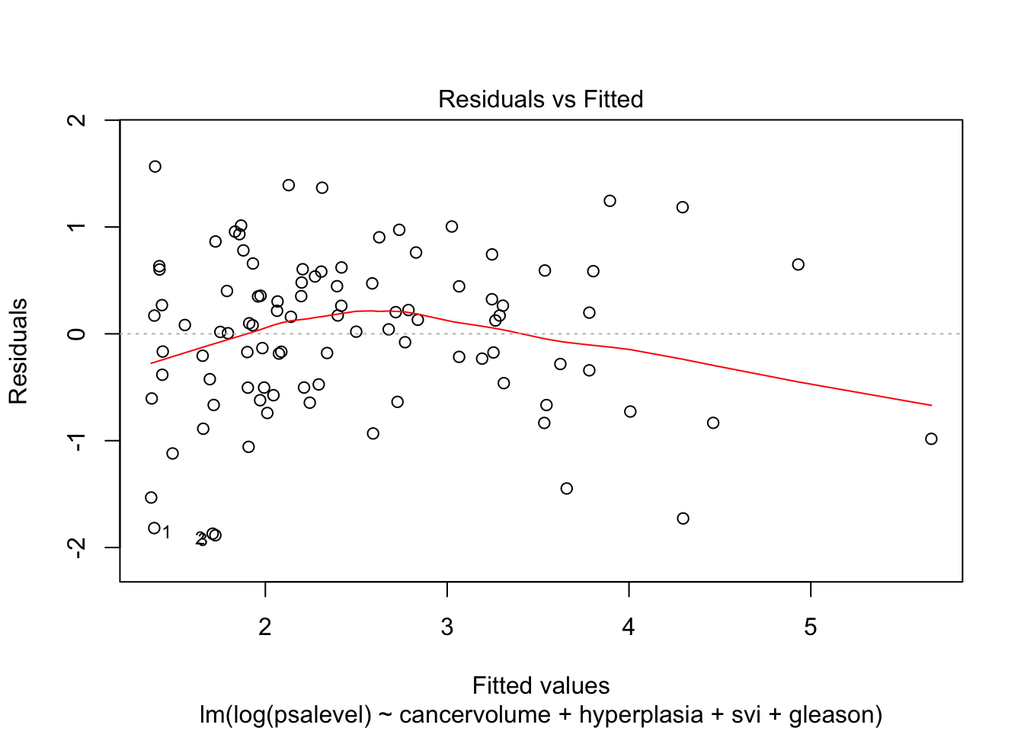

```r
# Checking Homoskedasticity

plot(model6, which=1)
```

```r
bptest(model6)
```

```
##
##  studentized Breusch-Pagan test
##
## data:  model6
## BP = 3.1199, df = 4, p-value = 0.538
```

The variance is now constant!

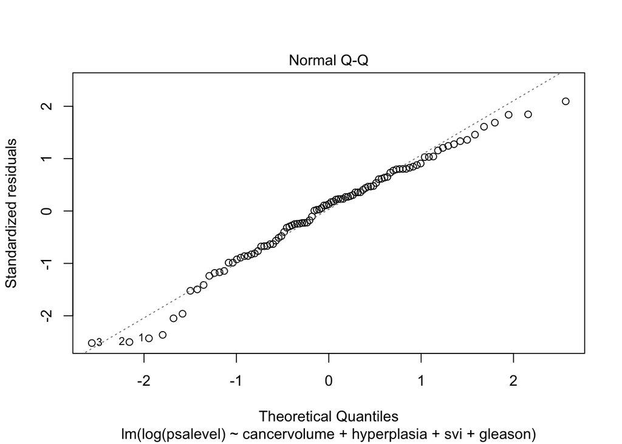

```r
# Normality
plot(model6, which=2)
```

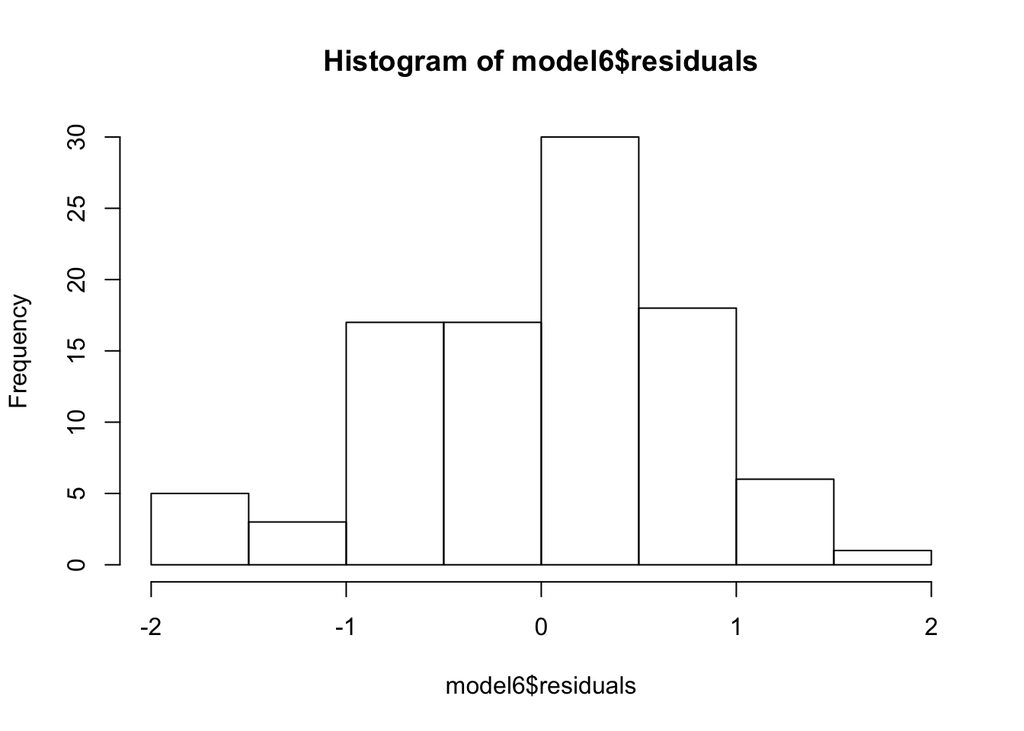

```r
hist(model6$residuals)
```

```r
ks.test(residuals(model6), y=pnorm)
```

```
##
##  One-sample Kolmogorov-Smirnov test
##
## data:  residuals(model6)
## D = 0.10389, p-value = 0.2296
## alternative hypothesis: two-sided
```

and the normality assumption now holds!

We also check the added-variables plots to see whether a transformation of any pf the predictors is needed.

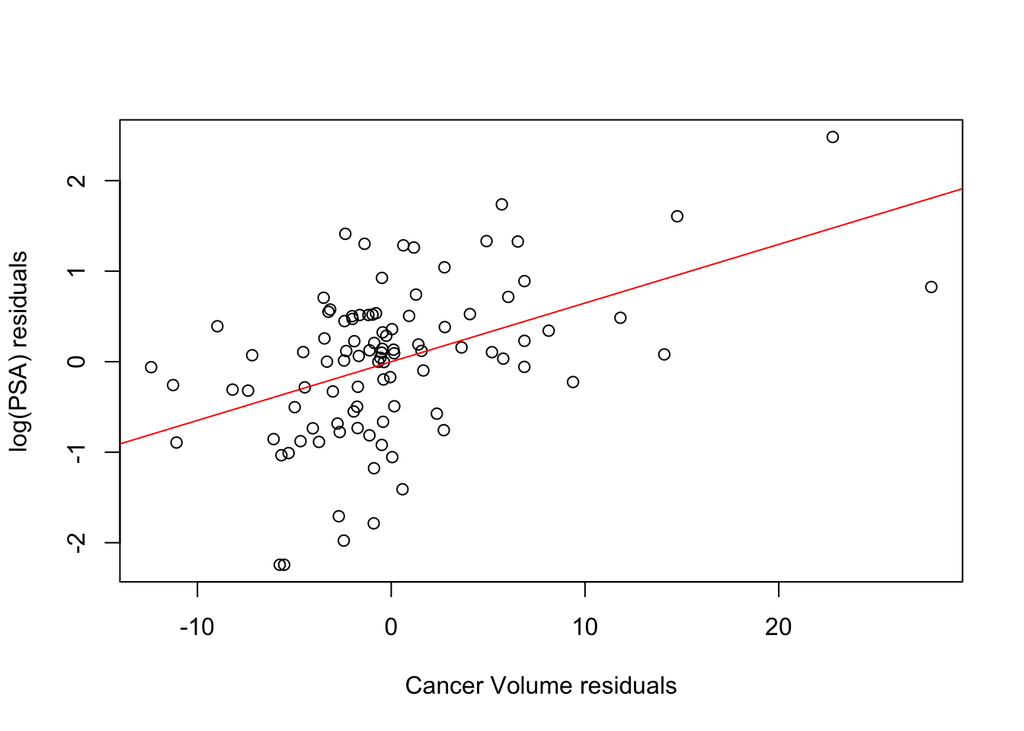

```r
# Added Variables Plots
# model6 = lm(log(psalevel) ~ cancervolumne   + hyperplasia + svi  + gleason, data=psa.data)

model6a1 = lm(log(psalevel) ~ hyperplasia + svi  + gleason, data=psa.data)
model6a2 = lm(cancervolume ~     hyperplasia + svi  + gleason, data=psa.data)
reg.a = lm(model6a1$residuals ~ model6a2$residuals)

model6b1 = lm(log(psalevel) ~ cancervolume  + svi  + gleason, data=psa.data)
model6b2 = lm(hyperplasia ~ cancervolume + svi  + gleason, data=psa.data)
reg.b = lm(model6b1$residuals ~ model6b2$residuals)

model6c1 = lm(log(psalevel) ~ cancervolume  +hyperplasia   + gleason, data=psa.data)
model6c2 = lm(svi ~ cancervolume + hyperplasia   + gleason, data=psa.data)
reg.c = lm(model6c1$residuals ~ model6c2$residuals)


model6d1 = lm(log(psalevel) ~ cancervolume  + hyperplasia   + svi , data=psa.data)
model6d2 = lm(gleason ~ cancervolume + hyperplasia   + svi , data=psa.data)
reg.d = lm(model6d1$residuals ~ model6d2$residuals)


# Added variables plots

plot(model6a2$residuals, model6a1$residuals, xlab="Cancer Volume residuals", ylab="log(PSA) residuals")
abline(reg.a, col="red")
```

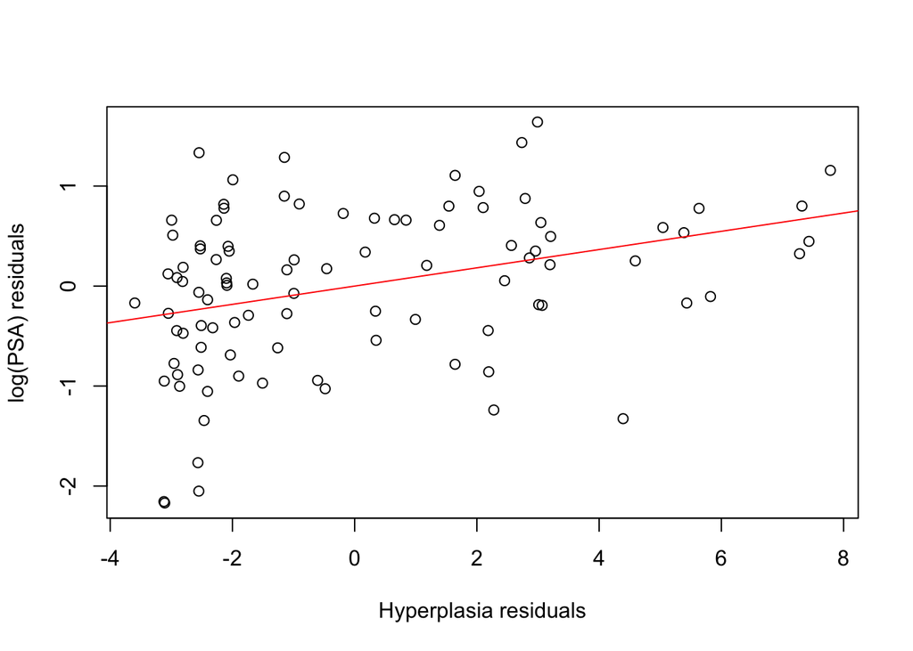

```r
plot(model6b2$residuals, model6b1$residuals, xlab="Hyperplasia residuals", ylab="log(PSA) residuals")
abline(reg.b, col="red")
```

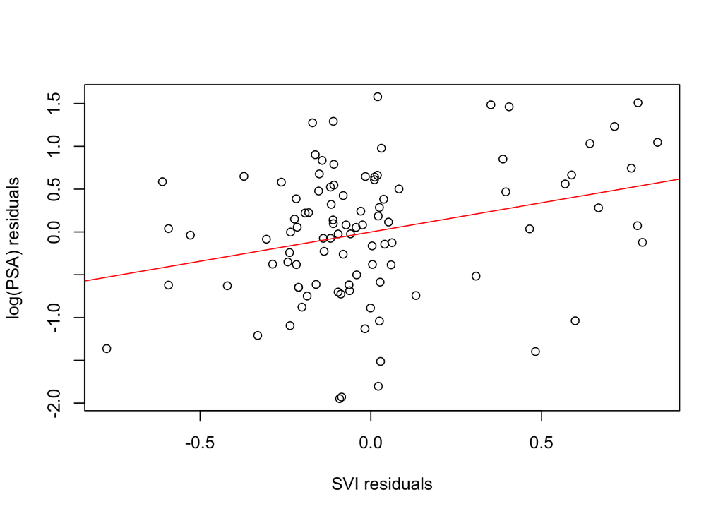

```r
plot(model6c2$residuals, model6c1$residuals, xlab="SVI residuals", ylab="log(PSA) residuals")
abline(reg.c, col="red")
```

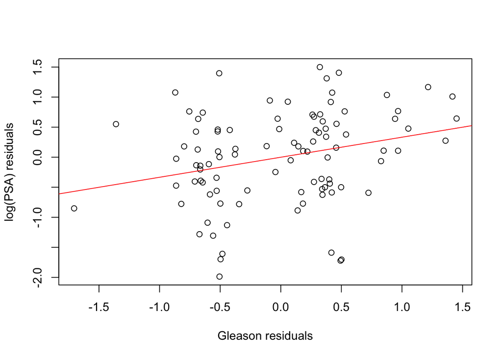

```r
plot(model6d2$residuals, model6d1$residuals, xlab="Gleason residuals", ylab="log(PSA) residuals")
abline(reg.d, col="red")
```

In this case, we have managed to find a suitable model to fit the data that explains the variation in the response in an adequate way.

So, what is next?